# Transfer function

Doynikov A.N.

2023-01-17

# 1 Модель передаточной функции

## 1.1 Кросс-ковариационная, кросс-корреляционная функция

Пусть $x_{t},y_{t},t=0,±1,±2,...,$ - стационаpные случайные пpоцессы в шиpоком смысле, т.е.
$$Ex_{t}=μ_{x},Ey_{t}=μ_{y}$$
$$Dx_{t}=σ_{x}²,Dy_{t}=σ_{y}²$$
$$c_{x}(t,t+m)=E(x_{t}-μ_{x})(x_{t+m}-μ_{x})=c_{x}(m)$$
$$c_{y}(t,t+m)=E(y_{t}-μ_{y})(y_{t+m}-μ_{y})=c_{y}(m)$$
Кpосс-коваpиационная функция процессов $x_{t},y_{t}$ опpеделяется фоpмулой
$$c_{xy}(s,t)=E(x_{s}-μ_{x})(y_{t}-μ_{y});
s,t=0,±1,±2,...$$
Cтационаpные случайные пpоцессы и называются совместно стационаpными в шиpоком смысле, если
$$c_{xy}(t,t+m)=E(x_{t}-μ_{x})(y_{t+m}-μ_{y})=c_{xy}(m); m=0,±1,±2,...$$

Кpосс-коваpиационная функция паpы пpоцессов выpажает меpу линейной зависимости значений $x_{t+m}и y_{t}$. Следует заметить, что кpосс-коваpиационная функция, вообще говоpя, не является симметpичной функцией аpгумента m. Веpно следующее соотношение
$$c_{xy}(m)=c_{yx}(-m)$$
Наиболее частое использование кpосс-коваpиационной функции иллюстpиpуется следующим пpимеpом. Пусть пpоцессы и связаны соотношением $y_{t}=Ax_{t-d}$ где $d$ - целое число. Говоpят, что $x_{t}$ опеpежает $y_{t }$ на $d$ шагов, если $d > 0$, и отстает от $y_{t }$ на $d$ шагов, если $d < 0$. Пpедположим для пpостоты, что $Ex_{t}=0,Ey_{t}=0$. Тогда кpосс-коваpиационная функция паpы пpоцессов $x_{t}$ и $y_{t}$ pавна
$$c_{xy}(m)=Ex_{t+m}y_{t}=AEx_{t+m}x_{t-d}=Ac_{x}(m+d)$$

Продемонстрируем это свойство автокорреляции на процессе авторегрессии первого порядка

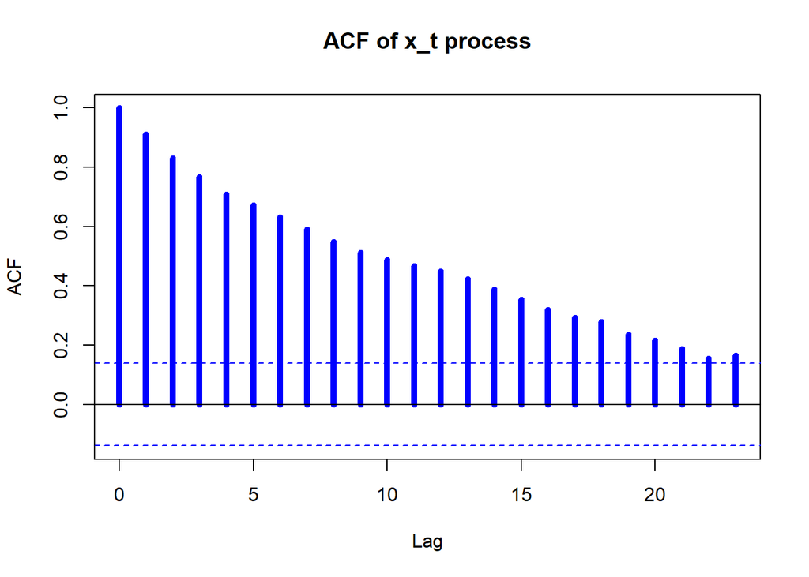

```r
fi <- 0.9
sigma <- 2
model <- list(ar = fi)
x <- arima.sim(model=model,n = 200,innov=rnorm(200,0,sd=sigma))
acf(x,main = "ACF of x_t process",lwd = 5,col = "blue")
```

```r
d <- 5
y <- x[d:200]
z <- x[1:(200-d+1)]
cross <- ccf(y,z,lwd = 5, main = "Cross-correlation of x_t and y_t",col = "blue")
```

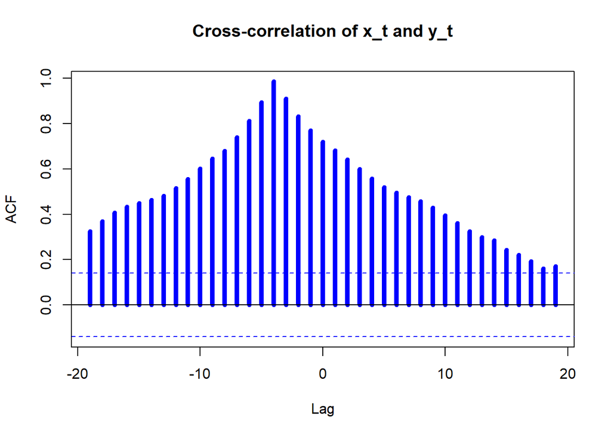

## 1.2 Передаточные функции

Модели передаточной функции описывают динамическую взаимосвязь между выходом $Y_t$ и одним или несколько входов $X_{j,t}$. Особенно большой интерес эти модели имеют в тех случаях, когда выходная переменная явно зависит от входных переменных с некоторым запаздыванием. Расскажу историю из своей практики. В начале нулевых годов некоторая фирма, проводящая маркетинговые исследования на заказ обратилась ко мне помочь провести исследование собраных данных описывающих влияние рекламной компании на продажи пива. В качестве входных переменных $X_{j,t}$ были количество денег, затраченных на рекламу в неделю, число минут рекламного времени по телевизору в неделю и т.п. Выходными переменными были итоги различных опросов: знают не знают сорт , употребляют ли регулярно и тому подобное, что конечно влияют на продажи за неделю конкретного сорта пива.

Важную роль в определении передаточной функции играет так называемая *Функция отклика на единичный импульс* (англ.*the impulse response function (IRF)*), которая для каждой входной переменной $X_{j,t}$ имеет вид бесконечного полинома
$$\nu_j(B)=\nu_{0,j}+\nu_{1,j}B+\nu_{2,j}B^2+....$$
часто ее можно представить виде отношения конечных полиномов
$$\nu_j(B)=\omega_{j,0}\frac{\omega_{j,s_j}(B)}{\delta_{j,r_j}(B)}B^{b_j}$$
где $s_j,r_j$ - степени полиномов в числителе и знаменателе,

$$\omega_{j,s_j}(B)= 1
-\omega_{j,1}B-\omega_{j,2}B^2-...-\omega_{j,s_j}B^{s_j}$$
$$\delta_{j,r_j}(B)= 1
-\delta_{j,1}B-\delta_{j,2}B^2-...-\delta_{j,r_j}B^{r_j}$$
в некоторых выдачах множитель $\omega_{j,0}$ перед функцией в числителе $\omega_{j,s_j}(B)$ вносят внутрь функции, перемножая $\omega_{j,0}\omega_{j,s_j}(B)$ и после переобозначения коэффициентов произведения записывают
$$\hat\omega_{j,s_j}(B)= \omega_{j,0}
-\hat\omega_{j,1}B-\hat\omega_{j,2}B^2-...-\hat\omega_{j,s_j}B^{s_j}$$

Объединяя вышеприведенные выражения , мы получаем достаточно богатый класс линейных моделей TF (transfer function) для выхода $Y_t$, заданного через функции импульсного откликов (IRF) для $k$ входов $X_{j,t},j=1,...,k$.

$$Y_t=\sum_{j=1}^k\omega_{j,0}\frac{\omega_{j,s_j}(B)}{\delta_{j,r_j}(B)}B^{b_j}X_{j,t}+N_t$$
$$\delta_d(B)N(t)=\frac{\theta_q(B)}{\phi_p(B)}a_t$$
где шум $N_t$ следует общей модели `ARIMA(p, d, q)`.

Для примера рассмотрим пример с данными по работе газовой печи, которые прилагаются к библиотеке. Это классический пример из книги авторов этой модели Бокса-Дженкинса. На вход идет расход входного газа в кубических футах в минуту, подаваемого в печь газа, на выходе % CO2 в выходном газе.

```r
library(tfarima)
data <- cbind(seriesJ$Y,seriesJ$X)
head(data)
```

```
##      seriesJ$Y seriesJ$X
## [1,]      53.8    -0.109
## [2,]      53.6     0.000
## [3,]      53.5     0.178
## [4,]      53.5     0.339
## [5,]      53.4     0.373
## [6,]      53.1     0.441
```

[figure not shown]

```r
matplot(data,type ='b',col=c('red','blue'),pch = 21,main = 'Gas furnace data')
legend('topright',c('Input','Output'),col=c('red','blue'),lty=1)
grid()
```

Сначала уберем средние

```r
Y <- seriesJ$Y - mean(seriesJ$Y)
X <- seriesJ$X - mean(seriesJ$X)
```

Сначала идентифицируем ARMA модель $N(t)$ для входа

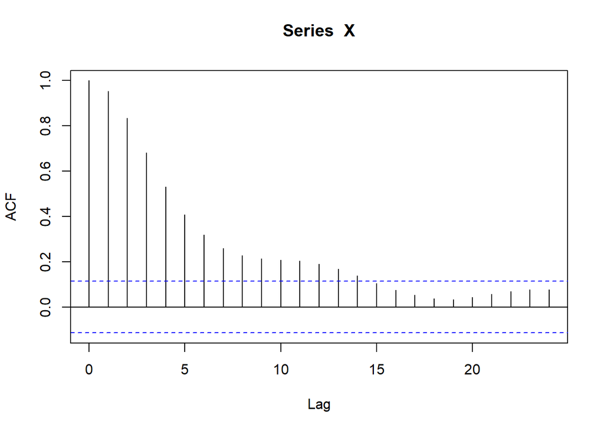

```r
acf(X)
```

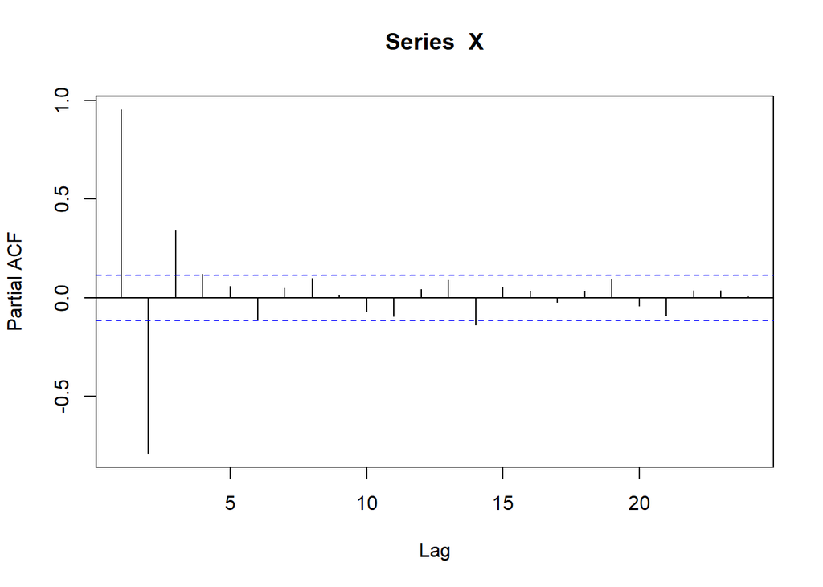

```r
pacf(X)
```

Модель AR(3) явно подойдет. Оценим ее. В библиотеке есть удобный метод для этого.

```r
umx <- um(X, ar = 3)
summary(umx)
```

```
##
## Model:
##  umx  <-  um(z = X, ar = 3)
##
## Time series:
## X
##
## Maximum likelihood method:
##  exact
##
## Coefficients:
##       Estimate  Gradient Std. Error z Value Pr(>|z|)
## phi1  1.969066  0.025676   0.054319  36.250  < 2e-16 ***
## phi2 -1.365145 -0.006166   0.098434 -13.869  < 2e-16 ***
## phi3  0.339409  0.021603   0.054340   6.246 4.21e-10 ***
## ---
## Signif. codes:  0 '***' 0.001 '**' 0.01 '*' 0.05 '.' 0.1 ' ' 1
##
## Total nobs                  296 Effective nobs              296
## log likelihood            72.57 Error variance           0.0353
## Mean of residuals    -8.192e-05 SD of the residuals      0.1882
## z-test for residuals   -0.00749 p-value                   0.994
## Ljung-Box Q(1) st.        9.153 p-value                0.002483
## Ljung-Box Q(74) st.       69.96 p-value                  0.6116
## Barlett H(3) stat.        23.42 p-value               8.211e-06
## AIC                     -0.4701 BIC                     -0.4327
```

В качестве модели для выхода также будем использовать AR(3) модель, так как  
модель шума в выходном ряде используется AR(3) модель входа.

```r
umy <- fit(umx, Y)
summary(umy)
```

```
##
## Model:
##  umy  <-  um(z = X, ar = 3)
##
## Time series:
## Y
##
## Maximum likelihood method:
##  exact
##
## Coefficients:
##      Estimate Gradient Std. Error z Value Pr(>|z|)
## phi1  2.19620  0.07726    0.05131  42.799   <2e-16 ***
## phi2 -1.68402 -0.01722    0.09648 -17.455   <2e-16 ***
## phi3  0.46046  0.07483    0.05149   8.942   <2e-16 ***
## ---
## Signif. codes:  0 '***' 0.001 '**' 0.01 '*' 0.05 '.' 0.1 ' ' 1
##
## Total nobs                  296 Effective nobs              296
## log likelihood           -104.1 Error variance           0.1159
## Mean of residuals      0.002383 SD of the residuals      0.3409
## z-test for residuals     0.1203 p-value                  0.9043
## Ljung-Box Q(1) st.        15.38 p-value               8.774e-05
## Ljung-Box Q(74) st.       89.59 p-value                  0.1047
## Barlett H(3) stat.        27.99 p-value               8.377e-07
## AIC                       0.724 BIC                      0.7614
```

Остатки для модели входа и модели выхода с учетом модели входа

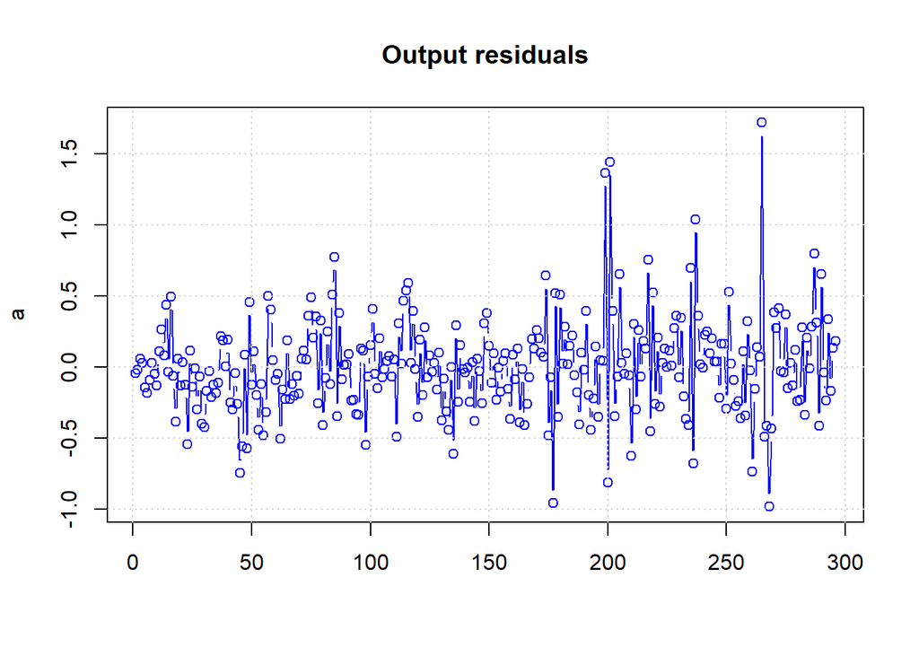

```r
a <- residuals(umy, Y, method = "cond")
matplot(a,type='b',main ='Output residuals',col = 'blue',pch =21)
grid()
```

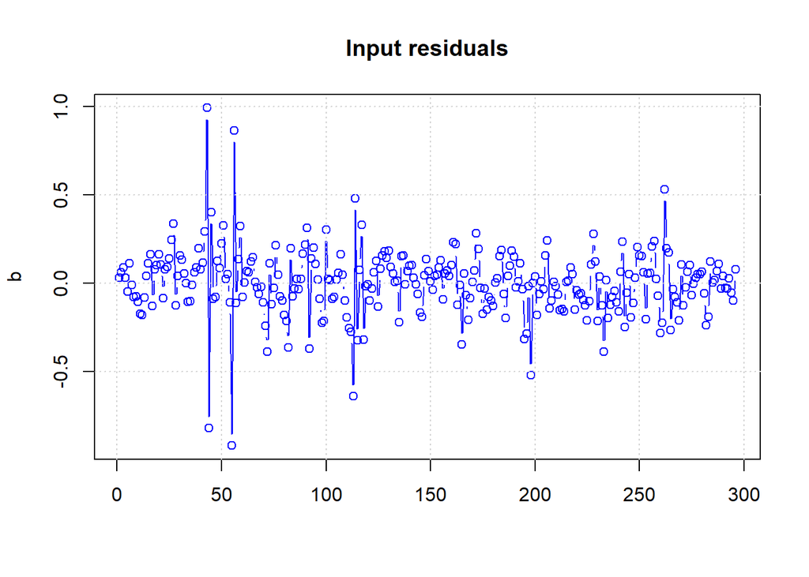

```r
b <- residuals(umx, X, method = "cond")
matplot(b,type='b',main ='Input residuals',col = 'blue',pch =21)
grid()
```

Определим задержку по времени между входом и выходом, вычислив кросс-корреляционную функцию входа и выхода meтодом из library(tfarima), который несколько отличен от стандартного `ccf()`. Поэтому ее и называют `Prewhitened cross correlation function` т.е. отбеленная кросс-корреляционная функция.

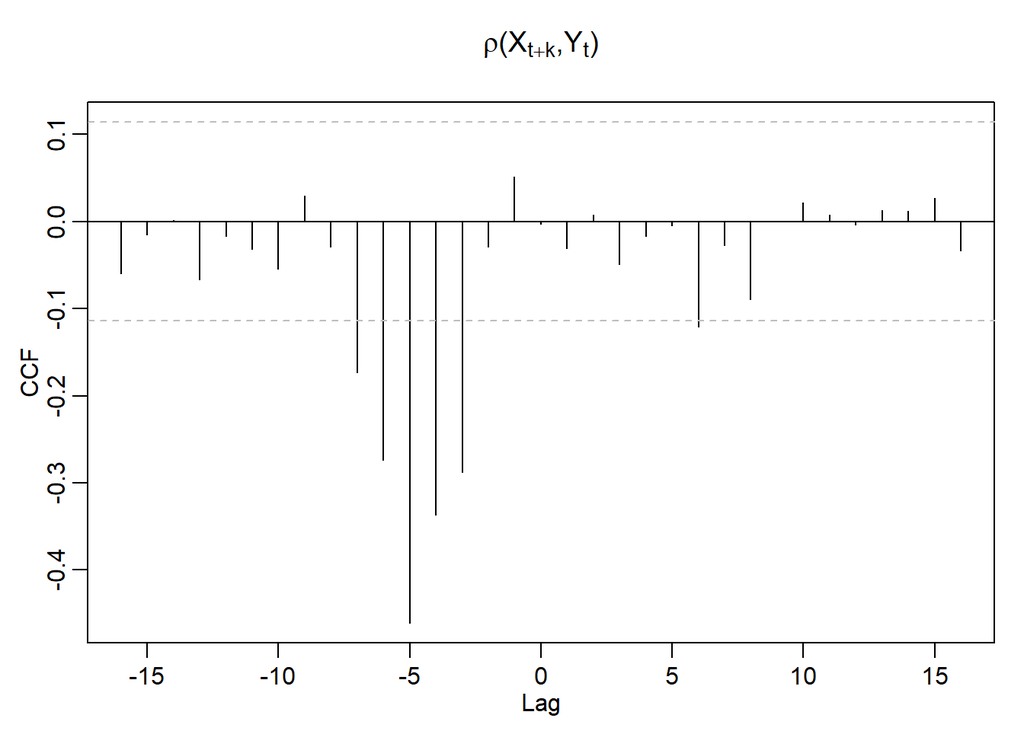

```r
pccf(X, Y, um.x = umx, um.y = NULL, lag.max = 16)
```

где

- X и Y — вход и выход,
- um.x и um.y — используемые одномерные ARMA модели, чтобы предварительно отбелить оба ряда X и Y,
- lag.max — это количество корреляций в каждой стороне.

Если оба um.х и um.y равны NULL, кросс-ковариационная функция оценивается без предварительного отбеливания и ее результат совпадет с методом со стандартным `ccf()`

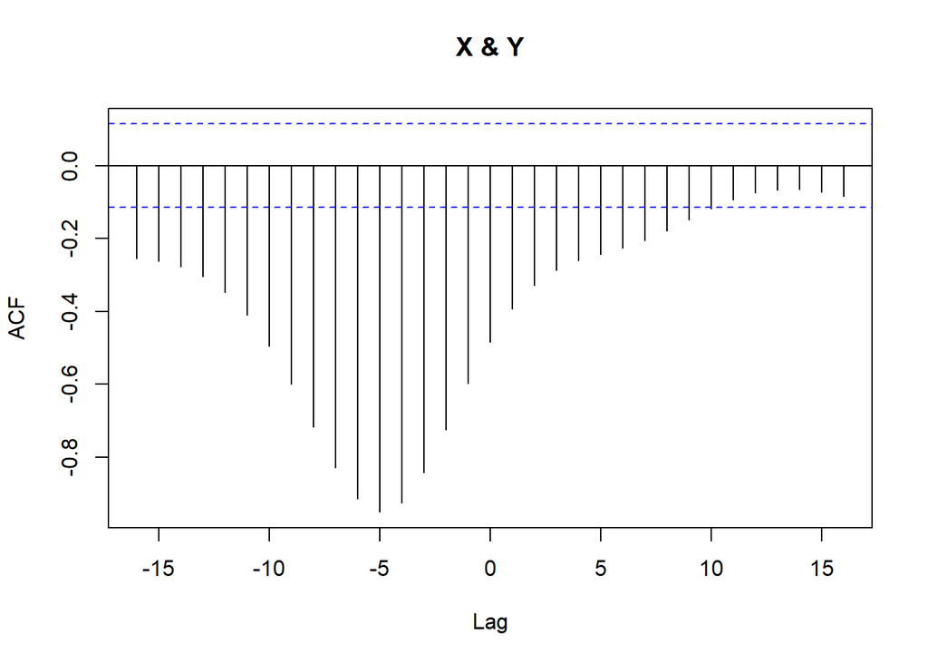

```r
ccf(X,Y,lag.max =16 )
```

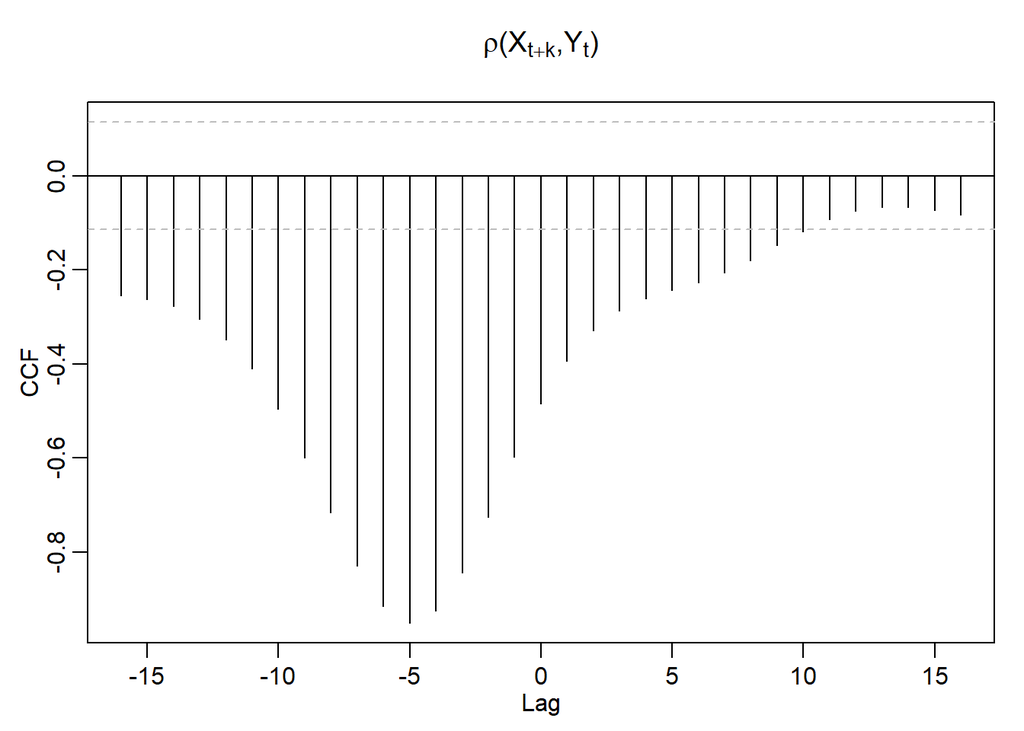

```r
pccf(X, Y, um.x = NULL, um.y = NULL, lag.max = 16)
```

Eсли только один из этих аргументов равен NULL, предоставленный um используется для предварительного отбеливания обоих рядов. В случае предоствления двух ARMA моделей `um` каждый ряд предварительно отбеливается своим `um`.

Итак, задержка в 5 единиц времени явно имеет место

С идентификацией порядков модели передаточной функции сложнее. Просто предположим что порядки полиномов числителя и знаменателя равны 2. Потом проведем коррекцию порядков модели, если потребуется.

Итак, предположим, что модель такая
$$Y_t=\frac{\omega_0-\omega_1B-\omega_2B^2}{1-\delta_1B-\delta_2B^2}B^5X_t+N_t$$
$$N_t=\frac{1}{1-\phi_1B-\phi_2B^2-\phi_3B^3}a_t$$

```r
tfx <- tfest(Y, X, delay = 5, p = 2, q = 2, um.x = umx, um.y = umy)
```

Оценим предложенную модель

```r
tfmy <- tfm(Y, inputs = tfx, noise = um(ar = 3))
```

Посмотрим на коэффициенты $\omega_0,\omega_1,\omega_2$. При этом будем использовать метод `printLagpol()`, который выдаст явный вид соответствующего полинома.

```r
printLagpol(tfmy$inputs[[1]]$theta,digits=3)
```

```
## - 1.04 - 1.35B - 0.407B^2
```

Коэффициенты $\delta_1,\delta_2$

```r
printLagpol(tfmy$inputs[[1]]$phi,digits=3)
```

```
## 1 + 0.771B - 0.163B^2
```

Наконец коэффициенты $\phi_1,\phi_2,\phi_3$

```r
 printLagpol(tfmy$noise$phi,digits=3)
```

```
## 1 - 1.79B + 1.07B^2 - 0.236B^3
```

Значимость оцененных коэффициентов как всегда можно так посмотреть

```r
summary(tfmy)
```

```
##
## Model:
##  tfmy  <-  tfm(output = Y, inputs = tfx, noise = um(ar = 3))
##
## Time series:
##   Y  ( 1.1  -  296.1 )
##
## Maximum likelihood method:
##  exact
##
## Coefficients:
##        Estimate   Gradient Std. Error z Value Pr(>|z|)
## X    -1.0362978  0.0021149  0.1093227  -9.479  < 2e-16 ***
## X.d1 -0.7707184 -0.0007098  0.1662085  -4.637 3.53e-06 ***
## X.d2  0.1634940 -0.0009818  0.1605243   1.018  0.30844
## X.w1 -1.3007287  0.0010702  0.2094400  -6.211 5.28e-10 ***
## X.w2 -0.3925163  0.0001114  0.2035241  -1.929  0.05378 .
## phi1  1.7937003  0.0558760  0.0656285  27.331  < 2e-16 ***
## phi2 -1.0729827 -0.0253110  0.1148285  -9.344  < 2e-16 ***
## phi3  0.2361254  0.0406219  0.0668267   3.533  0.00041 ***
## ---
## Signif. codes:  0 '***' 0.001 '**' 0.01 '*' 0.05 '.' 0.1 ' ' 1
##
## Total nobs                  296 Effective nobs              296
## log likelihood           -59.91 Error variance          0.08741
## Mean of residuals      0.004077 SD of the residuals      0.2946
## z-test for residuals     0.2381 p-value                  0.8118
## Ljung-Box Q(1) st.        1.918 p-value                  0.1661
## Ljung-Box Q(74) st.       75.77 p-value                  0.4211
## Barlett H(3) stat.        16.07 p-value               0.0003242
## AIC                      0.4588 BIC                      0.5586
```

Заметим, что оценку параметра $\delta_2$ можно считать равной 0. Так что порядок полинома $\delta(B)$ разумно сделать 1.

На практике часто просто устраивают перебор по возможным порядкам

```r
for (p in 1:3)
{
    for (q in 1:3)
    {
       tfx <- tfest(Y, X, delay = 5, p = p, q = q, um.x = umx, um.y = umy)
       tfmy <- tfm(Y, inputs = tfx, noise = um(ar = 3))
       smr <- summary(tfmy)
    }
}
```

и сравнивают результаты для критериев AIC,BIC, которые достают из выдачи `summary()` результатов оценивания модели, следят за изменением RSS суммы квадратов остатков при изменении порядков модели и т.д.

```r
smr <- summary(tfmy)
(aic <- smr$aic)
```

```
## [1] 0.4588191
```

```r
(bic <- smr$bic)
```

```
## [1] 0.5585585
```

```r
(rss <-smr$rss)
```

```
## [1] 26.13635
```

## 1.3 Прогнозирование по TF

Итак, будем считать, что модель наилучшем способом оценена и она содержится в переменной `tfmy`. Традиционно в R метод `predict()` осуществляет прогноз по модели, начиная прогноз с 5 наблюдения от конца ряда `Y` на `n.ahead = 10` единиц времени вперед. Доверительный интервал для прогноза задан уровня 0.95.

```r
nY <- length(Y)
forec <- predict(tfmy, n.ahead = 10, ori = nY-5,level = 0.95 )
```

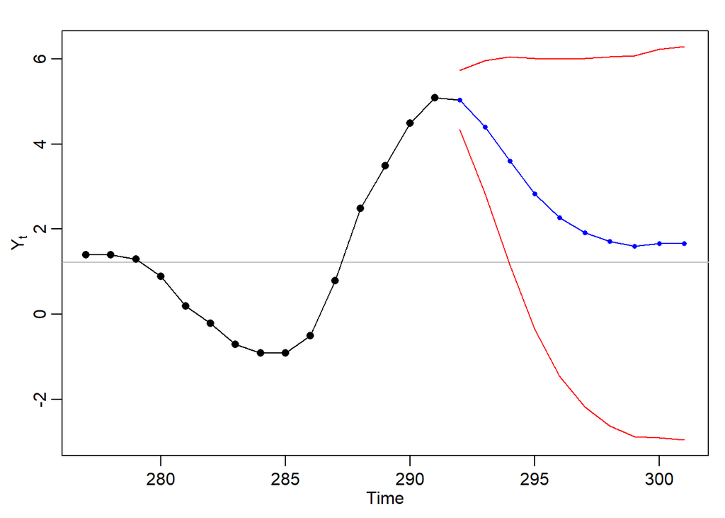

```r
plot(forec, n.back = 15, ylab = expression("Y"["t"]))
```

Если опустить параметр `ori`, то прогноз строится только для будущих значений ряда

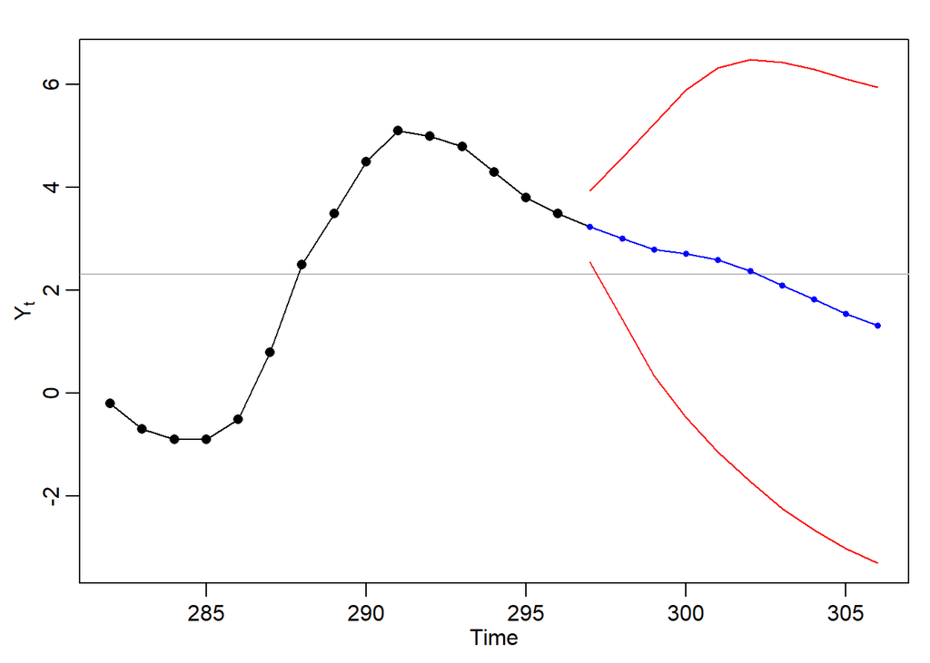

```r
forec <- predict(tfmy, n.ahead = 10,level = 0.95 )
plot(forec, n.back = 15, ylab = expression("Y"["t"]))
```

## 1.4 Моделирование

Сначала смоделируем временной ряд входа, как ARMA(1,1) модель

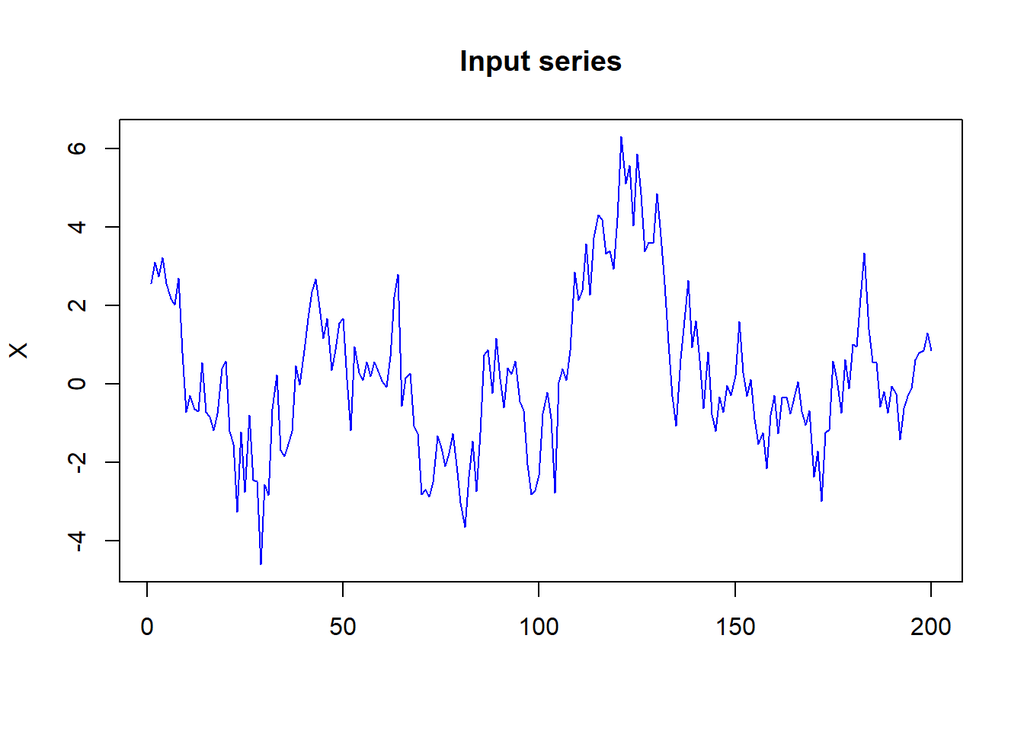

```r
fi <-0.9
theta <- -0.2
X <- arima.sim(n = 200, list(ar = c(fi), ma = c(theta)),
          sd = sqrt(1))
matplot(X,type ='l',col = 'blue', main = 'Input series')
```

Нам понадобится модель входа, ее можно оценить

```r
umx <- um(X, ar = 1,ma=1)
summary(umx)
```

```
##
## Model:
##  umx  <-  um(z = X, ar = 1, ma = 1)
##
## Time series:
## X
##
## Maximum likelihood method:
##  exact
##
## Coefficients:
##         Estimate  Gradient Std. Error z Value Pr(>|z|)
## phi1   9.029e-01 2.578e-05  3.405e-02  26.516   <2e-16 ***
## theta1 1.667e-01 1.160e-04  7.983e-02   2.088   0.0368 *
## ---
## Signif. codes:  0 '***' 0.001 '**' 0.01 '*' 0.05 '.' 0.1 ' ' 1
##
## Total nobs                  200 Effective nobs              200
## log likelihood           -285.9 Error variance            1.014
## Mean of residuals       0.02441 SD of the residuals       1.004
## z-test for residuals     0.3448 p-value                  0.7303
## Ljung-Box Q(1) st.       0.1524 p-value                  0.6962
## Ljung-Box Q(50) st.        52.5 p-value                  0.3774
## Barlett H(3) stat.        2.632 p-value                  0.2682
## AIC                       2.879 BIC                       2.912
```

Зададим передаточную функцию с задержкой 3, причем полиномы передаточной функции можно задать в явном виде

```r
tfx <- tf(X,delay = 3,w0 = 4.716, ar = "1-0.4B+0.5B^2",ma="1-0.5B")
```

Получим выходной ряд, с помощью специально сделанной в библиотеке функции

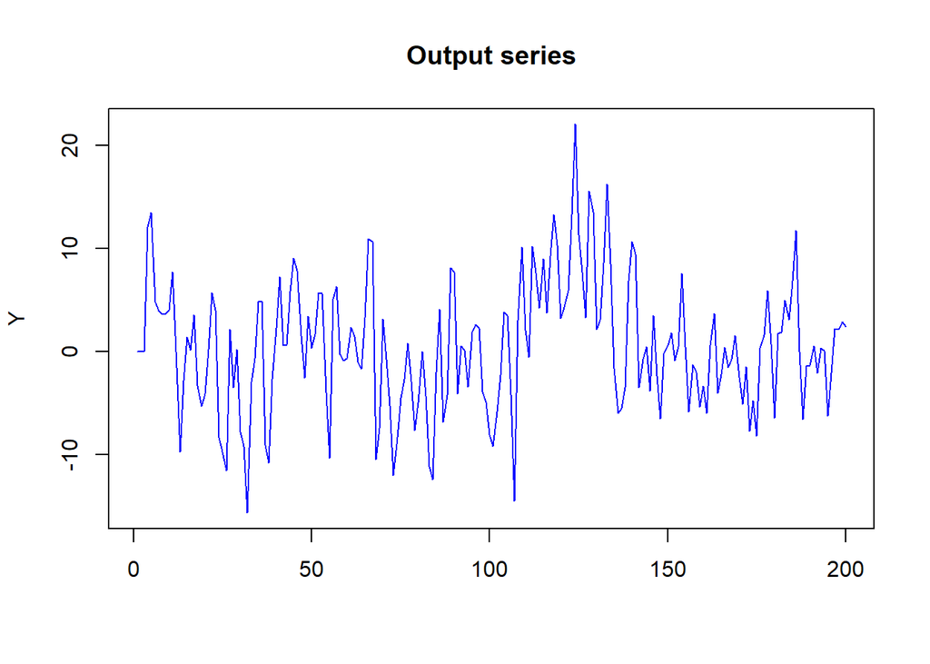

```r
Y <- output.tf(tfx)
matplot(Y,type ='l',col = 'blue', main = 'Output series')
```

Посмотрим на ACF,PACF выходного ряда

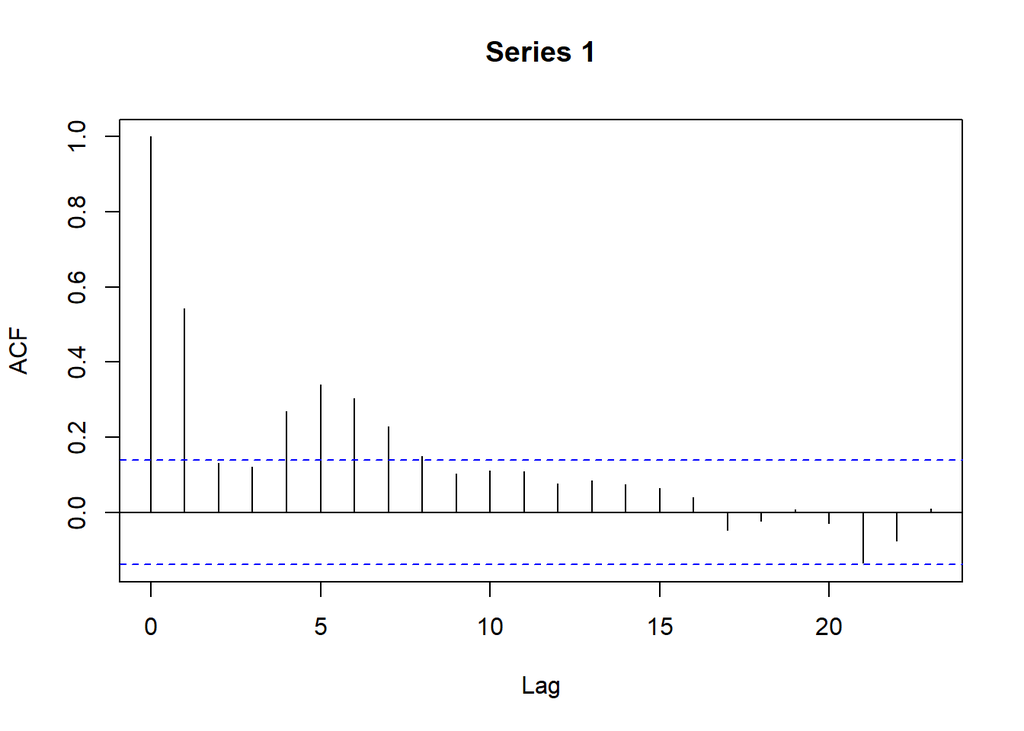

```r
acf(Y)
```

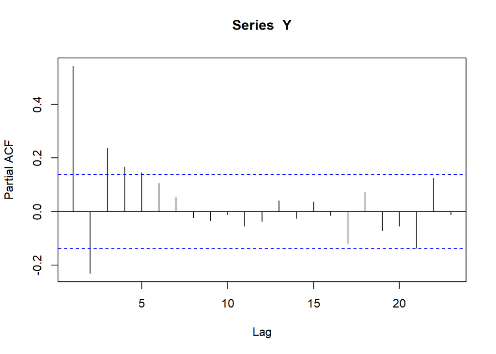

```r
pacf(Y)
```

Посмотрим кросс-корреляцию входа и выхода

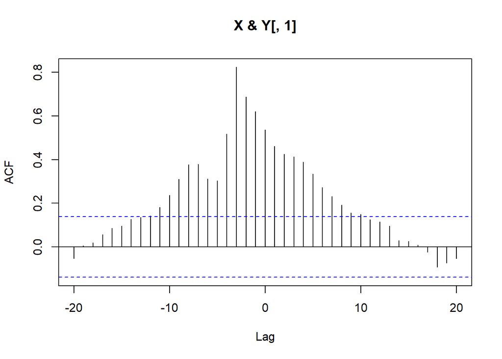

```r
ccf(X,Y[,1])
```

Создадим передаточную функцию и оценим ее

```r
tfx <- tfest(Y[,1],X, delay = 3, p = 2, q = 1, um.x = umx, um.y = umx)
tfmy <- tfm(Y[,1], inputs = tfx, noise = umx)
summary(tfmy)
```

```
##
## Model:
##  tfmy  <-  tfm(output = Y[, 1], inputs = tfx, noise = umx)
##
## Time series:
##   Y[, 1]  ( 1.1  -  200.1 )
##
## Maximum likelihood method:
##  exact
##
## Coefficients:
##          Estimate   Gradient Std. Error z Value Pr(>|z|)
## X       4.678e+00 -3.625e-04  5.410e-02  86.476  < 2e-16 ***
## X.d1    3.861e-01 -1.524e-03  1.438e-02  26.847  < 2e-16 ***
## X.d2   -5.040e-01  8.807e-03  9.633e-03 -52.321  < 2e-16 ***
## X.w1    4.929e-01 -1.140e-04  1.664e-02  29.629  < 2e-16 ***
## phi1    2.995e-01  5.413e-05  9.898e-02   3.026  0.00248 **
## theta1 -4.067e-01 -6.176e-05  8.697e-02  -4.676 2.93e-06 ***
## ---
## Signif. codes:  0 '***' 0.001 '**' 0.01 '*' 0.05 '.' 0.1 ' ' 1
##
## Total nobs                  200 Effective nobs              200
## log likelihood           -240.4 Error variance           0.6415
## Mean of residuals       -0.0288 SD of the residuals      0.7983
## z-test for residuals    -0.5116 p-value                   0.609
## Ljung-Box Q(1) st.        22.79 p-value               1.806e-06
## Ljung-Box Q(50) st.       38.63 p-value                  0.8788
## Barlett H(3) stat.        550.6 p-value              2.765e-120
## AIC                       2.464 BIC                       2.563
```